# DATA607 Week 5 Assignment

Gabriel Campos

March 19 2021

# Overview

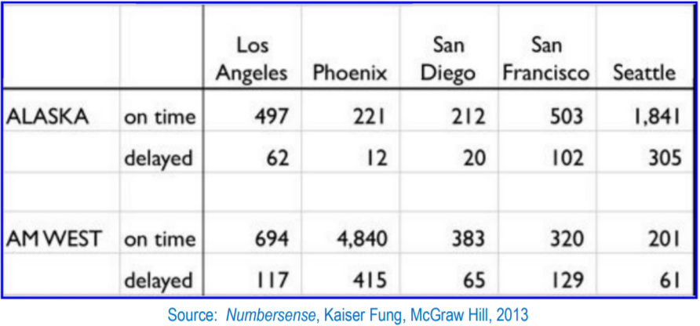

The chart above describes arrival delays for two airlines across five destinations. Your task is to:

1. Create a **.CSV file** (or **optionally**, a MySQL database!) that includes all of the information above.
   - You’re encouraged to use a “wide” structure similar to how the information appears above, so that you can practice tidying and transformations as described below.
2. Read the information from your **.CSV** file into$\ R$, and use `tidyr` and `dplyr` as needed to *tidy* and transform your data.
3. Perform **analysis to compare** the **arrival delays** for the **two airlines**.
4. Your code should be in an$\ R \ Markdown$ **file**, posted to RPUBS, and should include **narrative descriptions** of your **data cleanup work**, **analysis**, and **conclusions**. Please include in your homework submission:
   - The URL to the .Rmd file in your GitHub repository. and
   - The URL for your rpubs.com web page.

# Import Data

Data is imported from the `.csv` file located in my [github Week 5 folder](https://github.com/gcampos100/DATA607Spring2021/tree/main/Projects/Project%201). Function `read.csv` from the `utils` package is used.

```r
arrivals_delays <- read.csv(url, as.is = TRUE)
```

arrivals_delays

| X | X.1 | Los.Angeles | Phoenix | San.Diego | San.Francisco | Seattle |
| --- | --- | --- | --- | --- | --- | --- |
| ALASKA | on time | 497 | 221 | 212 | 503 | 1,841 |
|  | delayed | 62 | 12 | 20 | 102 | 305 |
|  |  | NA |  | NA | NA |  |
| AM WEST | on time | 694 | 4,840 | 383 | 320 | 201 |
|  | delayed | 117 | 415 | 65 | 129 | 61 |

NOTE:  
The present table reflects the NULL cells and unlabeled columns in the .csv file

# Cleanup

The above data set has a few problems that need correcting including:

- Removal of row comprised of empty cells () and `NA`
- Relabeling of column names for functional use
- Inserting logical data, for blank cells in column 1.

### `NA` Removal

The only row requiring removal is row 3. This is done using brackets `[ ]` in conjunction with `-` symbol to specify removal of the selected row.

```r
(arrivals_delays <- arrivals_delays[-3,])
```

```
##         X     X.1 Los.Angeles Phoenix San.Diego San.Francisco Seattle
## 1  ALASKA on time         497     221       212           503   1,841
## 2         delayed          62      12        20           102     305
## 4 AM WEST on time         694   4,840       383           320     201
## 5         delayed         117     415        65           129      61
```

### Relabeling of `colnames`

Since all but two columns are labeled correctly, a list of names is best to insert into the data frame.

```r
df_names <-
  c("Airline", "Arrival", "Los Angeles", "Phoenix",
    "San Diego", "San Francisco", "Seattle")

colnames(arrivals_delays) <- df_names
```

[output not shown]

### Inserting Data

The most logical data to place inside the empty cells in column one, is the *Airline* being referenced. Rather than manually type in the name I chose to reference the Airline name in the row before the blank one. Had this been a larger data set a *while loop* may have been a helpful tool.

```r
arrivals_delays[2,1]<-arrivals_delays[1,1]
arrivals_delays[4,1]<-arrivals_delays[3,1]
```

arrivals_delays

| Airline | Arrival | Los Angeles | Phoenix | San Diego | San Francisco | Seattle |
| --- | --- | --- | --- | --- | --- | --- |
| ALASKA | on time | 497 | 221 | 212 | 503 | 1,841 |
| ALASKA | delayed | 62 | 12 | 20 | 102 | 305 |
| AM WEST | on time | 694 | 4,840 | 383 | 320 | 201 |
| AM WEST | delayed | 117 | 415 | 65 | 129 | 61 |

## Transforming columns and rows

### Gather()

Using [gather() function](https://www.rdocumentation.org/packages/tidyr/versions/0.8.3/topics/gather) along with *pipe* `%>%` I reorganize the data so the counts and cities are accounted for on two columns.

- `key` is the name of the *new key* or column holding the previous **column names**
- `value` is the name of the column holding the **values** associated with said **key** values.

```r
(arrivals_delays_steps<-arrivals_delays %>%
  gather(key = "City",value = "Count", 3:7))
```

```
##    Airline Arrival          City Count
## 1   ALASKA on time   Los Angeles   497
## 2   ALASKA delayed   Los Angeles    62
## 3  AM WEST on time   Los Angeles   694
## 4  AM WEST delayed   Los Angeles   117
## 5   ALASKA on time       Phoenix   221
## 6   ALASKA delayed       Phoenix    12
## 7  AM WEST on time       Phoenix 4,840
## 8  AM WEST delayed       Phoenix   415
## 9   ALASKA on time     San Diego   212
## 10  ALASKA delayed     San Diego    20
## 11 AM WEST on time     San Diego   383
## 12 AM WEST delayed     San Diego    65
## 13  ALASKA on time San Francisco   503
## 14  ALASKA delayed San Francisco   102
## 15 AM WEST on time San Francisco   320
## 16 AM WEST delayed San Francisco   129
## 17  ALASKA on time       Seattle 1,841
## 18  ALASKA delayed       Seattle   305
## 19 AM WEST on time       Seattle   201
## 20 AM WEST delayed       Seattle    61
```

### Spread()

Using [spread() function](https://www.rdocumentation.org/packages/tidyr/versions/0.8.3/topics/spread)

- `key` is the column name or positions we are referencing.
- `values` are still the values affiliated with the key, but graphically the reference is lateral. Technically the shared relationship for these options is a single row.
- Columns $\ 2 \ \&\ 4$ are referenced. **e.g.**[^1]

```r
(arrivals_delays_steps<-arrivals_delays_steps %>%
  spread(key = 2,value = 4))
```

```
##    Airline          City delayed on time
## 1   ALASKA   Los Angeles      62     497
## 2   ALASKA       Phoenix      12     221
## 3   ALASKA     San Diego      20     212
## 4   ALASKA San Francisco     102     503
## 5   ALASKA       Seattle     305   1,841
## 6  AM WEST   Los Angeles     117     694
## 7  AM WEST       Phoenix     415   4,840
## 8  AM WEST     San Diego      65     383
## 9  AM WEST San Francisco     129     320
## 10 AM WEST       Seattle      61     201
```

### Arrange()

Using the [arrange() function](https://www.rdocumentation.org/packages/dplyr/versions/0.7.8/topics/arrange) I sort the data by city

```r
arrivals_delays_steps %>%
  arrange(City)
```

```
##    Airline          City delayed on time
## 1   ALASKA   Los Angeles      62     497
## 2  AM WEST   Los Angeles     117     694
## 3   ALASKA       Phoenix      12     221
## 4  AM WEST       Phoenix     415   4,840
## 5   ALASKA     San Diego      20     212
## 6  AM WEST     San Diego      65     383
## 7   ALASKA San Francisco     102     503
## 8  AM WEST San Francisco     129     320
## 9   ALASKA       Seattle     305   1,841
## 10 AM WEST       Seattle      61     201
```

### Single command

Alternatively all step can occur at once

```r
(arrivals_delays<-arrivals_delays %>%
  gather(key = "City",value = "Count", 3:7)%>%
    spread(key = 2,value = 4) %>%
        arrange(City))
```

```
##    Airline          City delayed on time
## 1   ALASKA   Los Angeles      62     497
## 2  AM WEST   Los Angeles     117     694
## 3   ALASKA       Phoenix      12     221
## 4  AM WEST       Phoenix     415   4,840
## 5   ALASKA     San Diego      20     212
## 6  AM WEST     San Diego      65     383
## 7   ALASKA San Francisco     102     503
## 8  AM WEST San Francisco     129     320
## 9   ALASKA       Seattle     305   1,841
## 10 AM WEST       Seattle      61     201
```

### Calculations

The Calculations are as follows:

- `Total Flights` = `delayed` + `on time` values by row.
- The for loop traverses each row, calculating `Total Flights` and storing it in the corresponding row.
- `Delay Rate` and `On Time Rate` are calculated by dividing entire columns:
  - `delayed`/`Total Flights`
  - `on time`/`Total Flights`

```r
# for loop to create totals
for(row in 1:nrow(arrivals_delays))
  arrivals_delays$`Total Flights`[row]<-
  as.numeric(arrivals_delays[row,3])+
  as.numeric(gsub(",","",arrivals_delays[row,4]))

#outside of for loop calculations for rates
  arrivals_delays$`Delay Rate`<-
    round( as.numeric( arrivals_delays$delayed ) / arrivals_delays$`Total Flights`,2 )

#arrival rates calculations
  arrivals_delays$`On Time Rate`<-
    round( as.numeric( gsub(",","",arrivals_delays$`on time` )) / arrivals_delays$`Total Flights`,2 )
```

arrivals_delays

| Airline | City | delayed | on time | Total Flights | Delay Rate | On Time Rate |
| --- | --- | --- | --- | --- | --- | --- |
| ALASKA | Los Angeles | 62 | 497 | 559 | 0.11 | 0.89 |
| AM WEST | Los Angeles | 117 | 694 | 811 | 0.14 | 0.86 |
| ALASKA | Phoenix | 12 | 221 | 233 | 0.05 | 0.95 |
| AM WEST | Phoenix | 415 | 4,840 | 5255 | 0.08 | 0.92 |
| ALASKA | San Diego | 20 | 212 | 232 | 0.09 | 0.91 |
| AM WEST | San Diego | 65 | 383 | 448 | 0.15 | 0.85 |
| ALASKA | San Francisco | 102 | 503 | 605 | 0.17 | 0.83 |
| AM WEST | San Francisco | 129 | 320 | 449 | 0.29 | 0.71 |
| ALASKA | Seattle | 305 | 1,841 | 2146 | 0.14 | 0.86 |
| AM WEST | Seattle | 61 | 201 | 262 | 0.23 | 0.77 |

# Conclusion

The summary below and the corresponding line graphs show, AM West varies greatly on its delay and on time rate by city, specifically regarding San Francisco. **ALASKA** airlines, however, fluctuates less and is consistently on time more with less delays on all major cities compared to **AM WEST**.

```
## # A tibble: 2 x 5
##   Airline `Avg Delay` `Avg Delay Rate` `On Time Avg` `On Time Avg Rate`
## * <chr>         <dbl>            <dbl>         <dbl>              <dbl>
## 1 ALASKA         100.            0.112          655.              0.888
## 2 AM WEST        157.            0.178         1288.              0.822
```

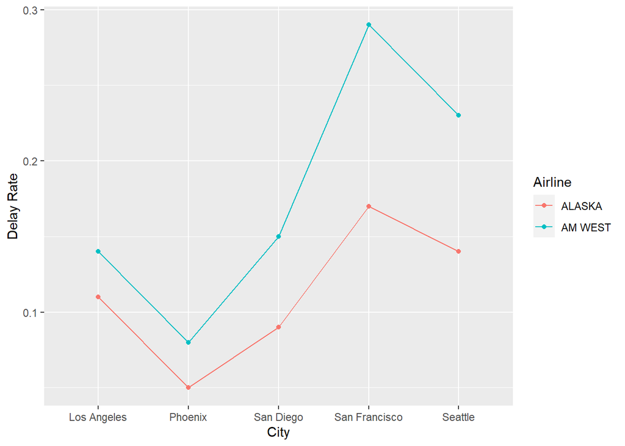

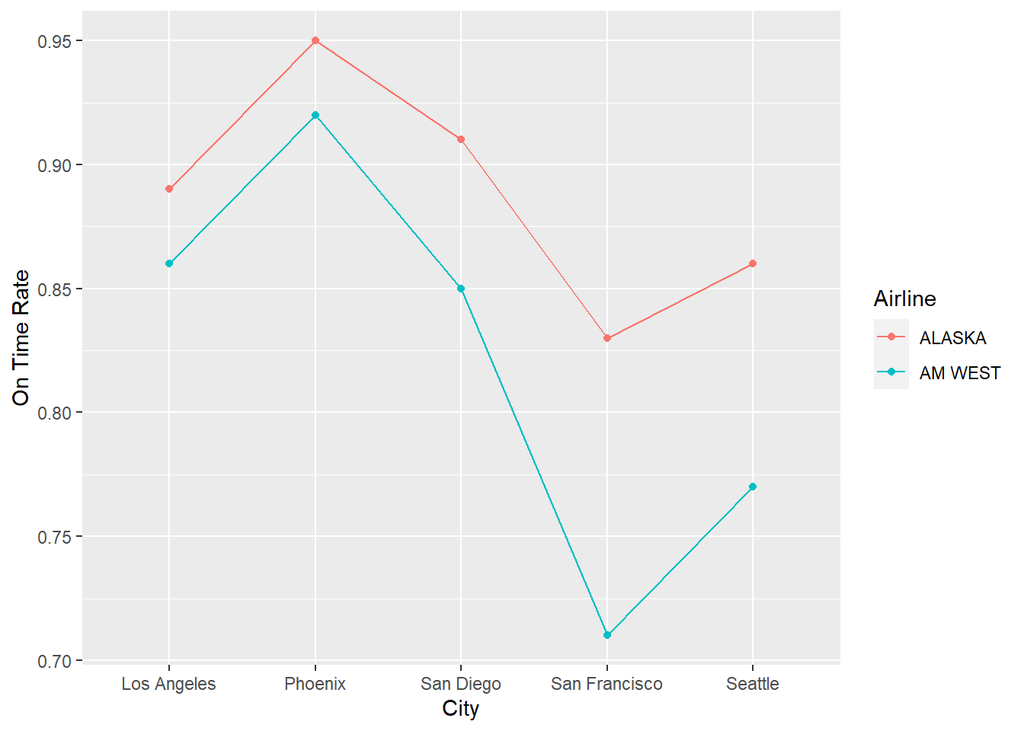